# DS202_Final

Repo for DS202 final project

```r
library(WDI)
library(dplyr)
library(tidyverse)
library(ggthemes)
```

# Changes in CO2 Emissions Over Time Members: Katherine Amundson, Kendra Scace, Gautham Suresh, Kelly Ryan

## **Introduction**

Understanding the historical trends of CO2 emissions is essential for crafting policies and strategies to mitigate their impact. In this project, we explore the changes in CO2 emissions overtime, focusing on different aspects such as the comparison of emission patterns between certain countries, impact of international agreements, and specific countries with the highest emissions. Along with that, we showed comparisons of CO2 emissions over time and the difference in emissions between developed and developing countries.

## <sub>**Data**</sub>

```r
df <- read.csv("CO2 emission by countries.csv")
head(df)
```

```
##       Country Code Calling.Code Year CO2.emission..Tons. Population.2022.
## 1 Afghanistan   AF           93 1750                   0         41128771
## 2 Afghanistan   AF           93 1751                   0         41128771
## 3 Afghanistan   AF           93 1752                   0         41128771
## 4 Afghanistan   AF           93 1753                   0         41128771
## 5 Afghanistan   AF           93 1754                   0         41128771
## 6 Afghanistan   AF           93 1755                   0         41128771
##     Area X..of.World Density.km2.
## 1 652230       0.40%    63/km\xb2
## 2 652230       0.40%    63/km\xb2
## 3 652230       0.40%    63/km\xb2
## 4 652230       0.40%    63/km\xb2
## 5 652230       0.40%    63/km\xb2
## 6 652230       0.40%    63/km\xb2
```

```r
length(df)
```

```
## [1] 9
```

```r
nrow(df)
```

```
## [1] 59620
```

```r
summary(df)
```

```
##    Country              Code           Calling.Code            Year
##  Length:59620       Length:59620       Length:59620       Min.   :1750
##  Class :character   Class :character   Class :character   1st Qu.:1817
##  Mode  :character   Mode  :character   Mode  :character   Median :1885
##                                                           Mean   :1885
##                                                           3rd Qu.:1953
##                                                           Max.   :2020
##
##  CO2.emission..Tons. Population.2022.         Area          X..of.World
##  Min.   :0.000e+00   Min.   :1.131e+04   Min.   :      21   Length:59620
##  1st Qu.:0.000e+00   1st Qu.:1.770e+06   1st Qu.:   17704   Class :character
##  Median :0.000e+00   Median :8.673e+06   Median :  110382   Mode  :character
##  Mean   :1.035e+09   Mean   :3.992e+07   Mean   :  652207
##  3rd Qu.:8.715e+06   3rd Qu.:2.863e+07   3rd Qu.:  492573
##  Max.   :4.170e+11   Max.   :1.426e+09   Max.   :17098242
##                      NA's   :6504        NA's   :4336
##  Density.km2.
##  Length:59620
##  Class :character
##  Mode  :character
##
##
##
##
```

The dataset contains information about CO2 emissions from different countries over a significant period, from 1750 to 2020. The dataset comprises 9 columns:

1. **Country**: Represents the name of the country.
2. **Code**: Corresponds to the country’s abbreviation or code.
3. **Calling Code**: Refers to the area code in a phone number associated with the country.
4. **Year**: Denotes the year when the data was observed.
5. **CO2 Emission (Tons)**: Represents the recorded amount of CO2 emissions by the country for a specific year.
6. **Population as of 2022**: Indicates the number of people living in the country as of the year 2022.
7. **Area**: Represents the size of the country in square kilometers.
8. **Percent of World**: Indicates the proportion of the Earth’s surface area occupied by the country.
9. **Density in km2**: Represents the population density of the country calculated as the number of people per square kilometer.

### **Dataset Overview:**

- The dataset contains 59,620 rows, each representing a unique combination of country, year, and associated data.
- The years covered in the dataset range from 1750 to 2020.
- The CO2 emissions column reveals a wide range of values, from 0 to 4.17e+11 (4.17e11 represents 4.17 multiplied by 10 to the power of 11).
- The population column shows variations in population size, with a minimum of 11,310 and a maximum of 1.426e+09 (1.426e09 represents 1.426 multiplied by 10 to the power of 9).
- The dataset also includes information about the size of each country, its share of the world, and population density.

```r
df <- drop_na(df)
```

### Data Exploration and Cleaning

```r
# checking for missing values
sum(is.na(df))
```

```
## [1] 0
```

```r
# removing rows with any missing values
df_clean <- na.omit(df)
#provides the structure of the dataframe, showing data types and the first few values of each variable, used for understanding the data types of each column
print("Structure: ")
```

```
## [1] "Structure: "
```

```r
str(df)
```

```
## 'data.frame':    50948 obs. of  9 variables:
##  $ Country            : chr  "Afghanistan" "Afghanistan" "Afghanistan" "Afghanistan" ...
##  $ Code               : chr  "AF" "AF" "AF" "AF" ...
##  $ Calling.Code       : chr  "93" "93" "93" "93" ...
##  $ Year               : int  1750 1751 1752 1753 1754 1755 1756 1757 1758 1759 ...
##  $ CO2.emission..Tons.: num  0 0 0 0 0 0 0 0 0 0 ...
##  $ Population.2022.   : int  41128771 41128771 41128771 41128771 41128771 41128771 41128771 41128771 41128771 41128771 ...
##  $ Area               : int  652230 652230 652230 652230 652230 652230 652230 652230 652230 652230 ...
##  $ X..of.World        : chr  "0.40%" "0.40%" "0.40%" "0.40%" ...
##  $ Density.km2.       : chr  "63/km\xb2" "63/km\xb2" "63/km\xb2" "63/km\xb2" ...
```

```r
# returns the names of the columns in the dataframe
print("Column names: ")
```

```
## [1] "Column names: "
```

```r
colnames(df)
```

```
## [1] "Country"             "Code"                "Calling.Code"
## [4] "Year"                "CO2.emission..Tons." "Population.2022."
## [7] "Area"                "X..of.World"         "Density.km2."
```

```r
#returns the class of the object
print("class: ")
```

```
## [1] "class: "
```

```r
sapply(df, class)
```

```
##             Country                Code        Calling.Code                Year
##         "character"         "character"         "character"           "integer"
## CO2.emission..Tons.    Population.2022.                Area         X..of.World
##           "numeric"           "integer"           "integer"         "character"
##        Density.km2.
##         "character"
```

```r
# returns the number of unique values for each variable in the dataframe. Helps with understanding the cardinality of each variable
print("unique values: ")
```

```
## [1] "unique values: "
```

```r
sapply(df, function(x) length(unique(x)))
```

```
##             Country                Code        Calling.Code                Year
##                 188                 184                 183                 271
## CO2.emission..Tons.    Population.2022.                Area         X..of.World
##               17000                 188                 188                  23
##        Density.km2.
##                 140
```

```r
# remove duplicate rows
df_unique <- unique(df)
# computes the correlation matrix for the numeric variables in the dataframe. Helps with understanding the relationships between different variables
print("correlation matrix: ")
```

```
## [1] "correlation matrix: "
```

```r
numeric_df <- df[sapply(df, is.numeric)]
cor_matrix <- cor(numeric_df)
print(cor_matrix)
```

```
##                             Year CO2.emission..Tons. Population.2022.
## Year                1.000000e+00           0.1393862     1.907900e-19
## CO2.emission..Tons. 1.393862e-01           1.0000000     1.620165e-01
## Population.2022.    1.907900e-19           0.1620165     1.000000e+00
## Area                2.892271e-19           0.2568388     4.434490e-01
##                             Area
## Year                2.892271e-19
## CO2.emission..Tons. 2.568388e-01
## Population.2022.    4.434490e-01
## Area                1.000000e+00
```

**Removing Rows with Missing Values:** clean the dataset by removing rows with any missing values

**Understanding the Data Structure:** The structure of the dataframe, including data types and the first few values of each variable, is printed.

**Column Names and Classes:** The names and classes of the columns in the dataframe are printed. The columns include “Country,” “Code,” “Year,” “CO2.emission..Tons.,” “Population.2022.,” “Area,” “X..of.World,” and “Density.km2.”. Classes range from character to integer and numeric.

**Unique Values and Cardinality:** The number of unique values for each variable in the dataframe is printed. The output provides insights into the cardinality of each variable.

**Questions to be addressed**

- Are currently developing countries polluting at rates similar to countries that industrialized earlier
- Have developed countries taken strides towards reducing pollution in the past decade?
- Have international agreements made any observable impact on emissions for participating countries?

## Exploring Unique Countries and Minimum CO2 Emission Years

### Unique Countries:

The unique countries present in the dataset are extracted and the head is printed.

This provides a list of distinct countries represented in the dataset.

```r
unique_countries <- unique(df$Country)

head(unique_countries)
```

```
## [1] "Afghanistan"         "Albania"             "Algeria"
## [4] "Andorra"             "Angola"              "Antigua and Barbuda"
```

### Filter Non-Zero CO2 Emissions:

This step involves excluding entries with zero CO2 emissions, focusing on non-zero emission instances. This filtered dataset has 21,707 rows and 9 columns.

```r
df <- df %>%
  filter(CO2.emission..Tons. != 0)
```

### Determining Minimum CO2 Emission Years:

```r
min_year_data <- df %>%
  group_by(Country) %>%
  filter(CO2.emission..Tons. != 0) %>%
  summarise(Min_Year = min(Year),
            CO2_Emission = CO2.emission..Tons.[which.min(Year)])

head(min_year_data)
```

```
## # A tibble: 6 × 3
##   Country             Min_Year CO2_Emission
##   <chr>                  <int>        <dbl>
## 1 Afghanistan             1949        14656
## 2 Albania                 1933         7328
## 3 Algeria                 1916         3664
## 4 Andorra                 1990       406704
## 5 Angola                  1950       186864
## 6 Antigua and Barbuda     1957        21984
```

## **Methods**

Our analysis involved various methods, including data cleaning, exploratory data analysis, and visualizations. The methods can be categorized into data handling, exploratory data analysis (EDA), and visualization techniques. The primary tools utilized for these tasks were the **`dplyr`** and **`ggplot2`** packages in R.

Our methodology encompassed thorough data cleaning, exploratory data analysis, and diverse visualizations to uncover patterns and trends in CO2 emissions across countries, with a specific focus on the impact of international agreements, top emitters, and the comparison between countries like China and the United States. The use of R packages, particularly **`dplyr`** and **`ggplot2`**, facilitated efficient data manipulation and visualization

## **Results**

### Changes Over Time

We started by examining how emissions have evolved over time for different countries. For countries with data available before 1900, we visualized their emission trends. This helped us identify early industrializers and compare their patterns with currently developing countries.

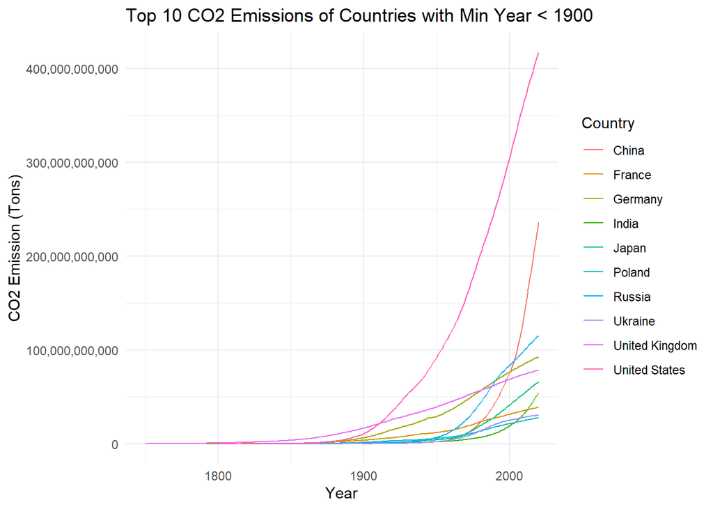

```r
# Filter countries with Min_Year < 1900
selected_countries <- min_year_data %>%
  filter(Min_Year < 1900)

# Filter data for selected countries
selected_df <- df %>%
  filter(Country %in% selected_countries$Country)

# Get the top 10 countries based on some criterion (e.g., average CO2 emissions)
top_10_countries <- selected_df %>%
  group_by(Country) %>%
  summarize(avg_emission = mean(CO2.emission..Tons.)) %>%
  top_n(10, wt = avg_emission) %>%
  pull(Country)

# Filter the data for the top 10 countries
selected_df_top10 <- selected_df %>%
  filter(Country %in% top_10_countries)

# Plotting
ggplot(selected_df_top10, aes(x = Year, y = CO2.emission..Tons., color = Country)) +
  geom_line() +
  labs(title = "Top 10 CO2 Emissions of Countries with Min Year < 1900",
       x = "Year",
       y = "CO2 Emission (Tons)") +
  theme_minimal() + scale_y_continuous(labels = scales::comma)
```

```r
population_threshold <- 75000000  # 75 million

large_countries <- df %>%
  filter(Population.2022. > population_threshold)
```

## Impact of International Agreements

We investigated whether international agreements have influenced CO2 emissions by examining emission trends for countries with populations exceeding 75 million. The visualizations included vertical lines representing the years of key international agreements. The Kyoto Protocol, created in 1997, and the Paris Agreement, enacted in 2015, are two of the most influential climate agreements to date, so we chose to use those as our markers.

### CO2 Emissions Compared to Dates of International Agreements

```r
countries_agreements <- large_countries %>%
  filter(Year > 1985)

head(countries_agreements)
```

```
##      Country Code Calling.Code Year CO2.emission..Tons. Population.2022.   Area
## 1 Bangladesh   BD          880 1986           157151542        171186372 147570
## 2 Bangladesh   BD          880 1987           168951269        171186372 147570
## 3 Bangladesh   BD          880 1988           182429710        171186372 147570
## 4 Bangladesh   BD          880 1989           195812073        171186372 147570
## 5 Bangladesh   BD          880 1990           209893669        171186372 147570
## 6 Bangladesh   BD          880 1991           224635652        171186372 147570
##   X..of.World Density.km2.
## 1       0.10% 1,160/km\xb2
## 2       0.10% 1,160/km\xb2
## 3       0.10% 1,160/km\xb2
## 4       0.10% 1,160/km\xb2
## 5       0.10% 1,160/km\xb2
## 6       0.10% 1,160/km\xb2
```

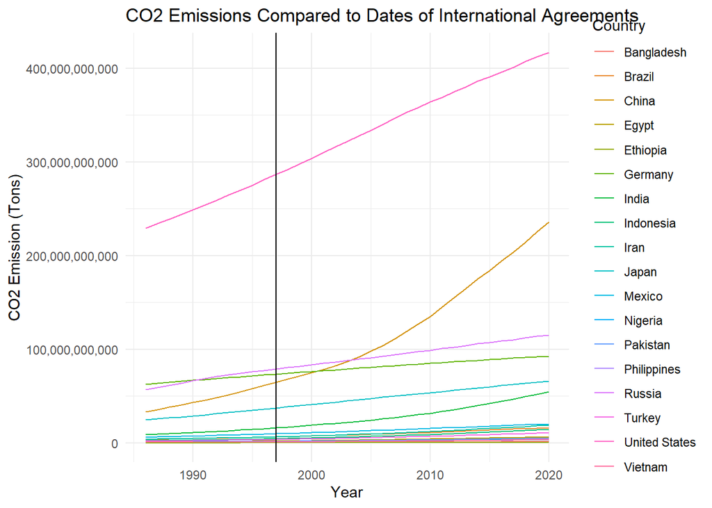

```r
agreements_years <- ggplot(countries_agreements, aes(x = Year, y = CO2.emission..Tons., color = Country)) +
  geom_line() +
  labs(title = "CO2 Emissions Compared to Dates of International Agreements",
       x = "Year",
       y = "CO2 Emission (Tons)") +
  theme_minimal() + scale_y_continuous(labels = scales::comma)
agreements_years + geom_vline(xintercept=1997)
```

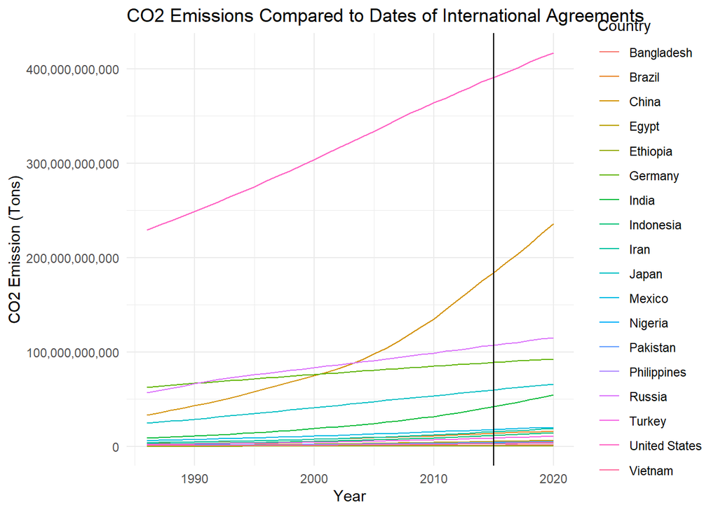

```r
agreements_years + geom_vline(xintercept=2015)
```

### Highest Emissions in 2020

We identified the top emitters in 2020 and visualized their emissions. This analysis provides insights into which countries contribute most to global emissions.

```r
largest_emissions <- df%>%
  filter(Year == 2020) %>%
  slice_max(CO2.emission..Tons., n = 10)

print(largest_emissions)
```

```
##           Country Code Calling.Code Year CO2.emission..Tons. Population.2022.
## 1   United States   US            1 2020        417000000000        338289857
## 2           China   CN           86 2020        236000000000       1425887337
## 3          Russia                 7 2020        115000000000        144713314
## 4         Germany   DE           49 2020         92635615097         83369843
## 5  United Kingdom   GB           44 2020         78161145636         67508936
## 6           Japan   JP           81 2020         65625166916        123951692
## 7           India   IN           91 2020         54416488997       1417173173
## 8          France   FR           33 2020         38728680794         64626628
## 9          Canada   CA            1 2020         33576743330         38454327
## 10        Ukraine   UA          380 2020         30559156342         39701739
##        Area X..of.World Density.km2.
## 1   9372610       6.10%    36/km\xb2
## 2   9706961       6.30%   147/km\xb2
## 3  17098242      11.00%     8/km\xb2
## 4    357114       0.20%   233/km\xb2
## 5    242900       0.20%   278/km\xb2
## 6    377930       0.20%   328/km\xb2
## 7   3287590       2.00%   431/km\xb2
## 8    551695       0.40%   117/km\xb2
## 9   9984670       6.10%     4/km\xb2
## 10   603500       0.40%    66/km\xb2
```

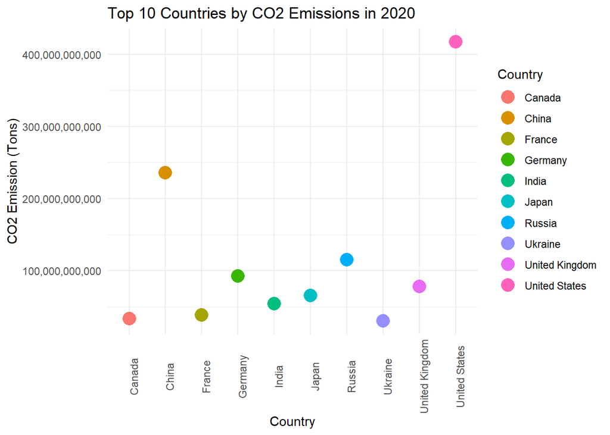

```r
most_emissions_graph<-ggplot(largest_emissions, aes(x=Country, y=CO2.emission..Tons., col=Country)) +
  geom_point(size = 5) +
    labs(title = "Top 10 Countries by CO2 Emissions in 2020",
       x = "Country",
       y = "CO2 Emission (Tons)") +
  theme_minimal() +
    theme(axis.text.x = element_text(angle = 90)) + scale_y_continuous(labels = scales::comma)



print(most_emissions_graph)
```

Next, we decided to compare emissions from countries with the highest populations. This would allow us to compare data and see whether countries with high populations also tend to create more CO2 emissions.

```r
emissions_2020 <- df %>%
  filter(Year==2020) %>%
  slice_max(Population.2022., n = 20)

highest_population_emissions<-ggplot(emissions_2020, aes(x=Country, y=CO2.emission..Tons., col=Country)) +
  geom_point(size = 5) + theme(axis.text.x = element_text(angle = 90, hjust = 1, vjust = 1)) + scale_y_continuous(labels = scales::comma)
    labs(title = "Emissions of the Top 20 Most Populated Countries in 2020",
       x = "Country",
       y = "CO2 Emission (Tons)")
```

```
## $x
## [1] "Country"
##
## $y
## [1] "CO2 Emission (Tons)"
##
## $title
## [1] "Emissions of the Top 20 Most Populated Countries in 2020"
##
## attr(,"class")
## [1] "labels"
```

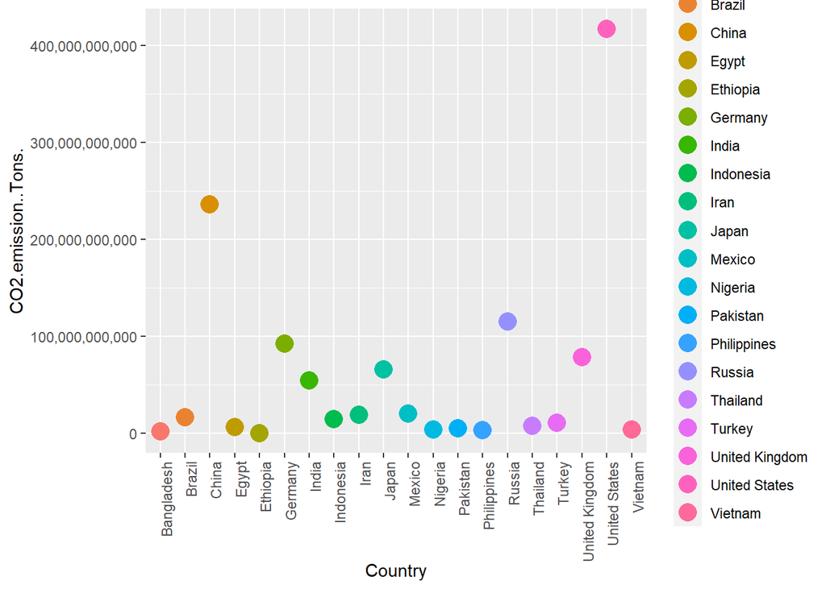

```r
print(highest_population_emissions)
```

### Global Distribution

To understand the geographical distribution of emissions in 2020, we created a world map highlighting each country’s contribution.

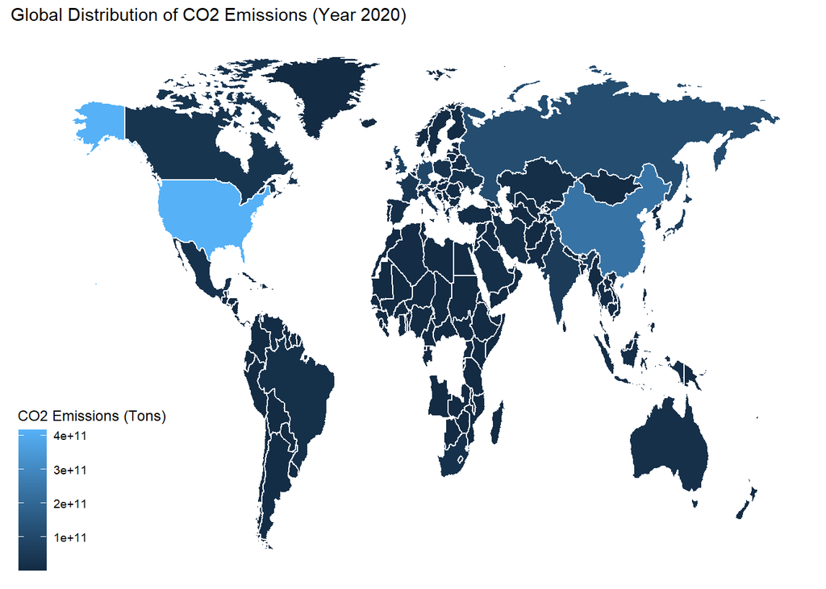

```r
# Load world map data
world_map <- map_data("world")
# Rename regions for consistency
world_map <- world_map %>%
  mutate(region = case_when(
    region == "UK"  ~ "United Kingdom",
    region == "USA" ~ "United States",
    TRUE ~ region
  ))
# Filter the data for the year 2020
df_2020 <- df %>% filter(Year == 2020)
# Perform inner join with the world map data
merged_data <- inner_join(world_map, df_2020, by = c("region" = "Country"))
# Plot the global distribution of CO2 emissions for the year 2020
ggplot(merged_data, aes(x = long, y = lat, group = group, fill = CO2.emission..Tons.)) +
  geom_polygon(color = "white") +
  labs(title = "Global Distribution of CO2 Emissions (Year 2020)",
       fill = "CO2 Emissions (Tons)") +
  theme_map()
```

*The map provides a visual representation of the global distribution of CO2 emissions, allowing for the identification of regions or countries with notable emission levels. Patterns and concentrations of high or low emissions can be observed, providing insights into the geographical variations of carbon dioxide output*

```r
valid_country_codes <- df %>%
  distinct(Code) %>%
  pull(Code)


wdi_data <- WDI(country = valid_country_codes, indicator =c("SP.POP.TOTL", "NY.GDP.MKTP.KD"))
wdi_data <- left_join(df, wdi_data, by = c("Code" = "iso2c", "Year" = "year"))

# WDI only contains population data from 1960
wdi_data <- wdi_data %>%
  filter(Year >= 1960)
```

### CO2 Emissions Comparison: China vs. United States

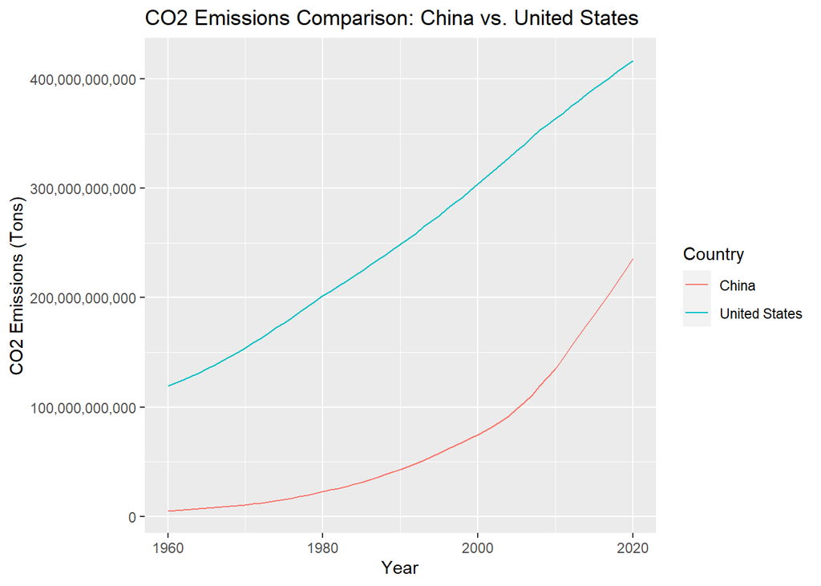

```r
china_us_data <- wdi_data %>%
  filter(Country %in% c("China", "United States"))

# Plot the pollution rates for China and the US
ggplot(china_us_data, aes(x = Year, y = CO2.emission..Tons., color = Country)) +
  geom_line() +
  labs(title = "CO2 Emissions Comparison: China vs. United States",
       x = "Year",
       y = "CO2 Emissions (Tons)",
       color = "Country") + scale_y_continuous(labels = scales::comma)
```

*Comparing CO2 US and China for the past 60 years shows a general trend where the emissions rate for China is climbing faster than the US. This lines up with historical context as companies tend to move manufacturing plants to countries with looser labor laws and restrictions.*

### Factors Influencing Emissions in the United States

We explored potential factors influencing emissions in the United States, including population size and GDP.

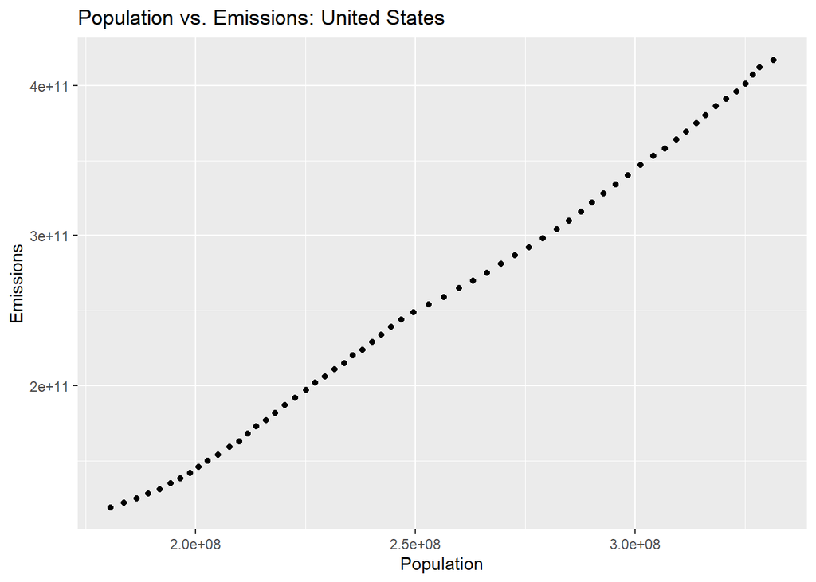

```r
us_data <- wdi_data %>%
  filter(Country == "United States")

# Plot population vs. emissions rate for the United States
ggplot(us_data, aes(x = SP.POP.TOTL, y = CO2.emission..Tons.)) +
  geom_point() +
  labs(title = "Population vs. Emissions: United States",
       x = "Population",
       y = "Emissions")
```

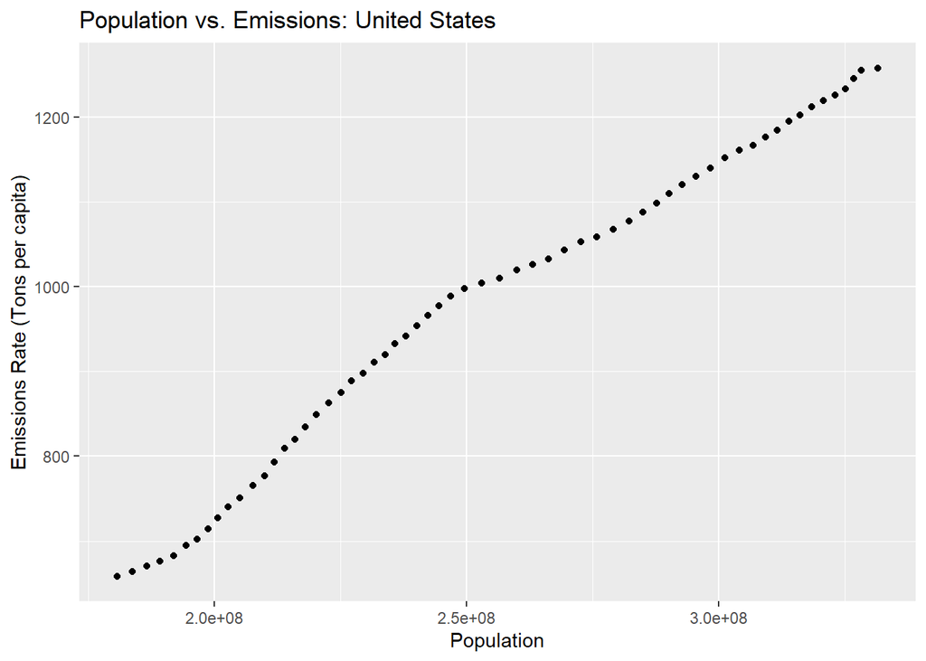

```r
ggplot(us_data, aes(x = SP.POP.TOTL, y = CO2.emission..Tons. / SP.POP.TOTL)) +
  geom_point() +
  labs(title = "Population vs. Emissions: United States",
       x = "Population",
       y = "Emissions Rate (Tons per capita)")
```

### GDP vs. CO2 Emissions: United States

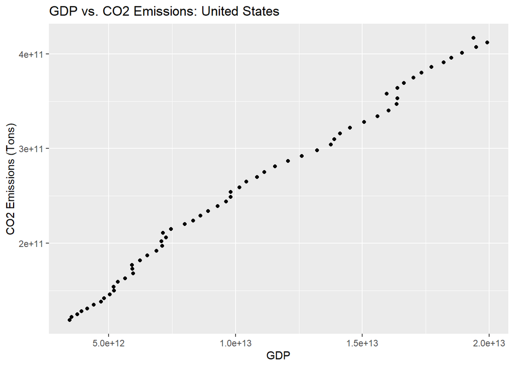

```r
ggplot(us_data, aes(x = NY.GDP.MKTP.KD, y = CO2.emission..Tons.)) +
  geom_point() +
  labs(title = "GDP vs. CO2 Emissions: United States",
       x = "GDP",
       y = "CO2 Emissions (Tons)")
```

*This graph higlights a trend where an increase in GDP contributes to increased C02 emissions*

### CO2 Emissions Comparison

In this section, we delve into a detailed analysis of CO2 emissions data, focusing on the year 2020. The dataset under consideration includes information on CO2 emissions, population figures, and additional pertinent variables across various countries.

1. Data Preprocessing:

Column Renaming: For enhanced readability and ease of use, columns were renamed. The column “CO2.emission..Tons.” was abbreviated to “coTons,” while “Population.2022.” became “population.”

Data Sorting: To facilitate subsequent analyses, the dataset was sorted in descending order based on population.

2. Analysis for the Year 2020:

Filtering Data: The dataset was filtered to exclusively include entries where the “Year” column corresponds to 2020.

Handling NaN Values: A subset of data was extracted where at least one value had NaN on all columns.

```r
# renaming so its easier to type
df1 <- df %>%
  rename(coTons = "CO2.emission..Tons.", population = "Population.2022.")

# sorts df1 based on the population column in descending order
df1 <- df1 %>%
  arrange(desc(population))

# getting all data from 2020
df2020 <- df1 %>%
  filter(Year == 2020)

head(df2020)
```

```
##         Country Code Calling.Code Year       coTons population    Area
## 1         China   CN           86 2020 236000000000 1425887337 9706961
## 2         India   IN           91 2020  54416488997 1417173173 3287590
## 3 United States   US            1 2020 417000000000  338289857 9372610
## 4     Indonesia   ID           62 2020  14399959936  275501339 1904569
## 5      Pakistan   PK           92 2020   5162288599  235824862  881912
## 6       Nigeria   NG          234 2020   3914990643  218541212  923768
##   X..of.World Density.km2.
## 1       6.30%   147/km\xb2
## 2       2.00%   431/km\xb2
## 3       6.10%    36/km\xb2
## 4       1.20%   145/km\xb2
## 5       0.50%   267/km\xb2
## 6       0.60%   237/km\xb2
```

```r
# filter where it returns all rows where one value has NaN on all columns
null2020 <- df2020 %>%
  filter(rowSums(is.na(.)) > 0)

null2020$Country
```

```
## character(0)
```

```r
num_rows <- nrow(null2020)
print(num_rows)
```

```
## [1] 0
```

```r
# Identify the most polluting country
theMostPolluting <- df2020[df2020$coTons == max(df2020$coTons, na.rm = TRUE), ]
theMostPolluting
```

```
##         Country Code Calling.Code Year   coTons population    Area X..of.World
## 3 United States   US            1 2020 4.17e+11  338289857 9372610       6.10%
##   Density.km2.
## 3    36/km\xb2
```

```r
# arrange in ascending order based on coTons column
sorted2020 <- df2020 %>% arrange(coTons)
head(sorted2020)
```

```
##                 Country Code Calling.Code Year  coTons population Area
## 1           Puerto Rico   PR 1-787, 1-939 2020  208848    3252407 8870
## 2                Tuvalu   TV          688 2020  278925      11312   26
## 3              Kiribati   KI          686 2020 2085306     131232  811
## 4 Sao Tome and Principe   ST          239 2020 3360735     227380  964
## 5      Marshall Islands   MH          692 2020 3416752      41569  181
## 6            Micronesia   FM          691 2020 3713305     114164  702
##   X..of.World Density.km2.
## 1       0.00%   367/km\xb2
## 2       0.00%   435/km\xb2
## 3       0.00%   162/km\xb2
## 4       0.00%   236/km\xb2
## 5       0.00%   230/km\xb2
## 6       0.00%   163/km\xb2
```

```r
mostPolluting <- df2020[order(-df2020$coTons), ][1, ]
head(mostPolluting)
```

```
##         Country Code Calling.Code Year   coTons population    Area X..of.World
## 3 United States   US            1 2020 4.17e+11  338289857 9372610       6.10%
##   Density.km2.
## 3    36/km\xb2
```

### Top 10 Countries in 2020

Focusing on the top 10 countries with the highest CO2 emissions in the year 2020. A subset of the dataset was created by selecting the top 10 countries with the highest CO2 emissions. It was visualized over the course of the year using a line plot with various colors. United States shows to be leading, while China is second and just over half of the US’s emissions.

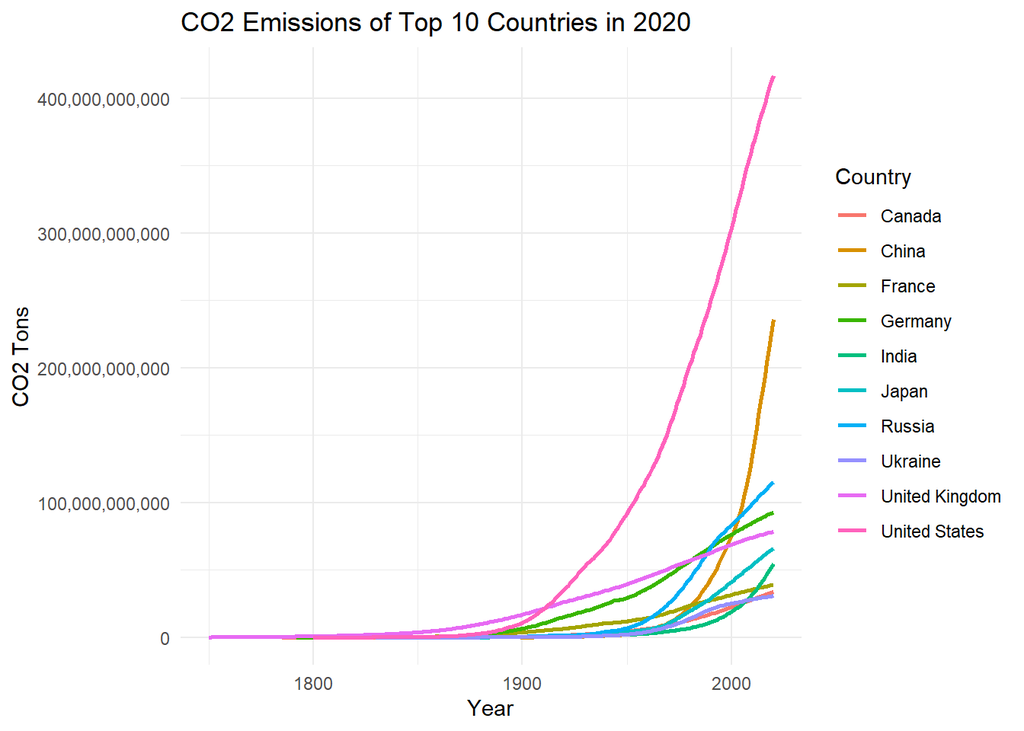

```r
# Select the top 10 countries with the highest CO2 emissions in 2020
top10_2020 <- df2020 %>% arrange(desc(coTons)) %>% head(10)

# Filter the original dataset for the selected countries
topCountriesCO2 <- df1 %>% filter(Country %in% top10_2020$Country)

# Plot the data using ggplot2
ggplot(topCountriesCO2, aes(x = Year, y = coTons, color = Country)) +
  geom_line(size = 1) +
  labs(title = "CO2 Emissions of Top 10 Countries in 2020",
       x = "Year",
       y = "CO2 Tons") +
  theme_minimal() + scale_y_continuous(labels = scales::comma)
```

Here is the start of the timeline throughout the centuries. This is starting at the beginning of the dataset, so it’s not a full century, only spanning 50 years. Around 1760 was the start of the Industrial Revolution, which meant an increase in CO2 emissions due to the increase of coal to fuel the Industrial Revolution.

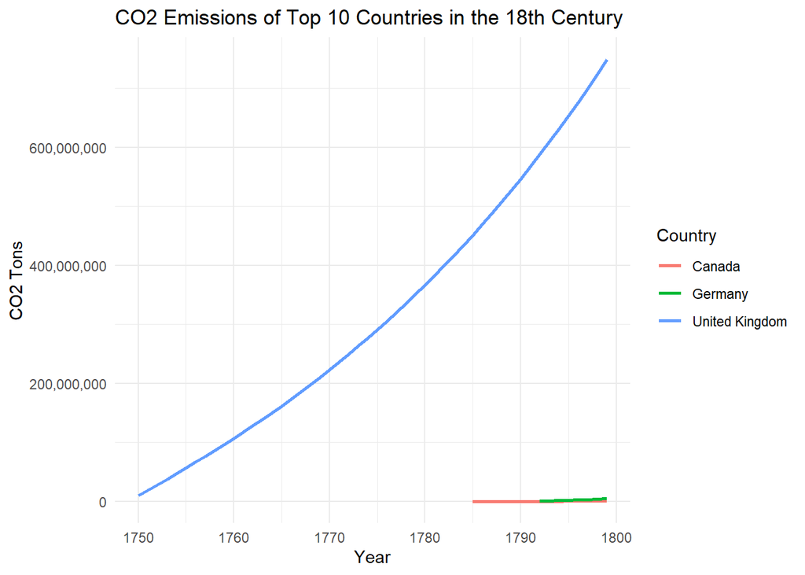

```r
# 18th century
cent_18 <- df1 %>% filter(Year >= 1750 & Year <= 1799)

# Select the top 10 countries with the highest CO2 emissions in the 19th century
big_cent_18 <- cent_18 %>%
  group_by(Country) %>%
  summarise(TotalCO2 = sum(coTons)) %>%
  arrange(desc(TotalCO2)) %>%
  head(10)

# Filter the original dataset for the selected countries in the 19th century
CO2_cent_18 <- cent_18 %>% filter(Country %in% big_cent_18$Country)

# Plot the data using ggplot2
ggplot(CO2_cent_18, aes(x = Year, y = coTons, color = Country)) +
  geom_line(size = 1) +
  labs(title = "CO2 Emissions of Top 10 Countries in the 18th Century",
       x = "Year",
       y = "CO2 Tons") +
  theme_minimal() + scale_y_continuous(labels = scales::comma)
```

Next, we have the 19th century. Here we see a drastic change, the United States made the top 10 and brought itself to second. Other countries made an appearance as well, adding to varying CO2 emissions by the turn of the century.

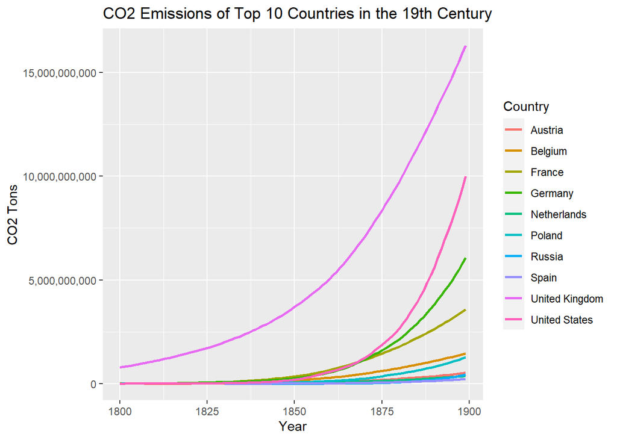

```r
# 19th century
cent_19 <- df1 %>% filter(Year >= 1800 & Year <= 1899)

# Select the top 10 countries with the highest CO2 emissions in the 19th century
big_cent_19 <- cent_19 %>%
  group_by(Country) %>%
  summarise(TotalCO2 = sum(coTons)) %>%
  arrange(desc(TotalCO2)) %>%
  head(10)

# Filter the original dataset for the selected countries in the 19th century
CO2_cent_19 <- cent_19 %>% filter(Country %in% big_cent_19$Country)

# Plot the data using ggplot2
ggplot(CO2_cent_19, aes(x = Year, y = coTons, color = Country)) +
  geom_line(size = 1) +
  labs(title = "CO2 Emissions of Top 10 Countries in the 19th Century",
       x = "Year",
       y = "CO2 Tons") + scale_y_continuous(labels = scales::comma)
```

Now we reach the 1900’s, at first glance the graph seems like the other countries didn’t add much to the CO2 emissions and the US just skyrocketed. If you look at the numbers on the y-axis, you will see that the US is just an outlier, and the other countries have actually doubled their CO2. Many factors could lead to this jump. One of them could be the post World-War II baby boom, an increase in population equals an increase in CO2 emissions.

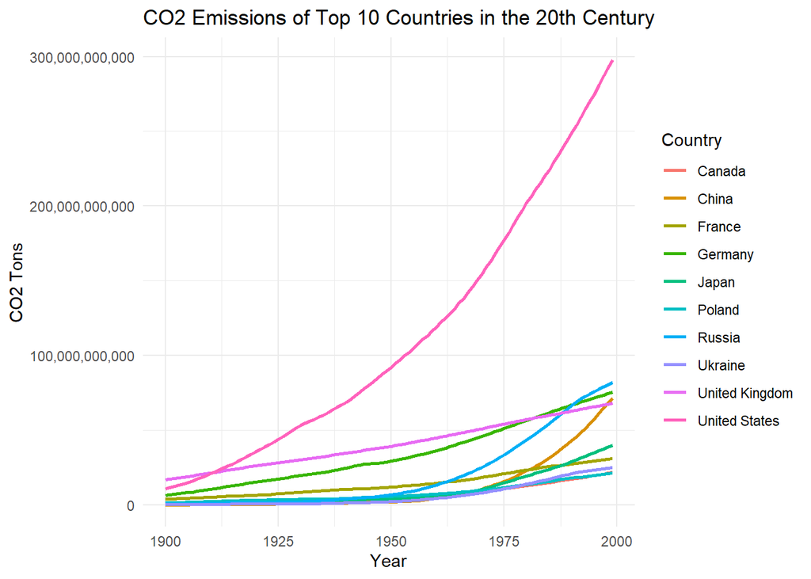

```r
# 20th century
# Filter the original dataset for the 20th century
cent_20 <- df1 %>% filter(Year >= 1900 & Year <= 1999)

# Select the top 10 countries with the highest CO2 emissions in the 20th century
big_cent_20 <- cent_20 %>%
  group_by(Country) %>%
  summarise(TotalCO2 = sum(coTons)) %>%
  arrange(desc(TotalCO2)) %>%
  head(10)

# Filter the original dataset for the selected countries in the 20th century
CO2_cent_20 <- cent_20 %>% filter(Country %in% big_cent_20$Country)

# Plot the data using ggplot2
ggplot(CO2_cent_20, aes(x = Year, y = coTons, color = Country)) +
  geom_line(size = 1) +
  labs(title = "CO2 Emissions of Top 10 Countries in the 20th Century",
       x = "Year",
       y = "CO2 Tons") +
  theme_minimal() + scale_y_continuous(labels = scales::comma)
```

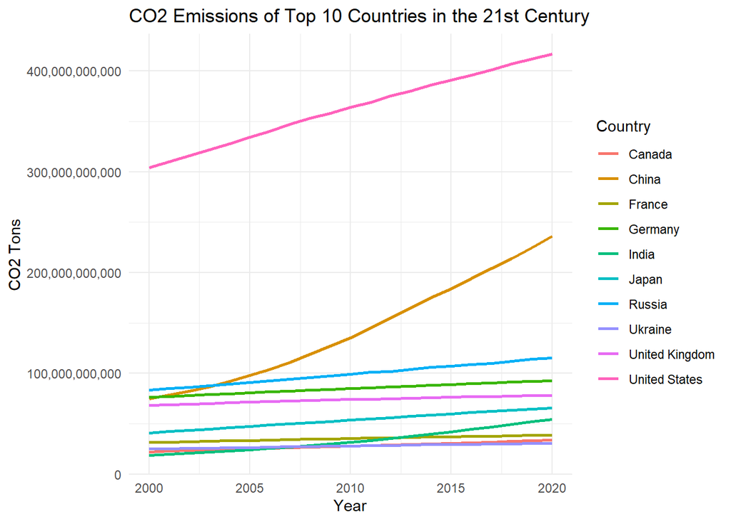

```r
# Filter the original dataset for the 21st century
cent_21 <- df1 %>% filter(Year >= 2000 & Year <= 2022)

# Select the top 10 countries with the highest CO2 emissions in the 21st century
big_cent_21 <- cent_21 %>%
  group_by(Country) %>%
  summarise(TotalCO2 = sum(coTons)) %>%
  arrange(desc(TotalCO2)) %>%
  head(10)

# Filter the original dataset for the selected countries in the 21st century
CO2_cent_21 <- cent_21 %>% filter(Country %in% big_cent_21$Country)

# Plot the data using ggplot2
ggplot(CO2_cent_21, aes(x = Year, y = coTons, color = Country)) +
  geom_line(size = 1) +
  labs(title = "CO2 Emissions of Top 10 Countries in the 21st Century",
       x = "Year",
       y = "CO2 Tons") +
  theme_minimal() + scale_y_continuous(labels = scales::comma)
```

### CO2 Emissions per Area

This graph shows the CO2 emissions per area for the top countries in 2020. Leading is the United Kingdom, their high figure suggests a concentrated impact on the environment despite its relatively smaller landmass. While on the opposite end is Canada, despite its expansive landmass, they produce less CO2 per Area than smaller countries.

```r
area2020 = top10_2020
area2020$coByArea <- area2020$coTons / area2020$Area
area2020
```

```
##           Country Code Calling.Code Year       coTons population     Area
## 1   United States   US            1 2020 417000000000  338289857  9372610
## 2           China   CN           86 2020 236000000000 1425887337  9706961
## 3          Russia                 7 2020 115000000000  144713314 17098242
## 4         Germany   DE           49 2020  92635615097   83369843   357114
## 5  United Kingdom   GB           44 2020  78161145636   67508936   242900
## 6           Japan   JP           81 2020  65625166916  123951692   377930
## 7           India   IN           91 2020  54416488997 1417173173  3287590
## 8          France   FR           33 2020  38728680794   64626628   551695
## 9          Canada   CA            1 2020  33576743330   38454327  9984670
## 10        Ukraine   UA          380 2020  30559156342   39701739   603500
##    X..of.World Density.km2.   coByArea
## 1        6.10%    36/km\xb2  44491.342
## 2        6.30%   147/km\xb2  24312.450
## 3       11.00%     8/km\xb2   6725.838
## 4        0.20%   233/km\xb2 259400.682
## 5        0.20%   278/km\xb2 321783.226
## 6        0.20%   328/km\xb2 173643.709
## 7        2.00%   431/km\xb2  16552.091
## 8        0.40%   117/km\xb2  70199.441
## 9        6.10%     4/km\xb2   3362.830
## 10       0.40%    66/km\xb2  50636.547
```

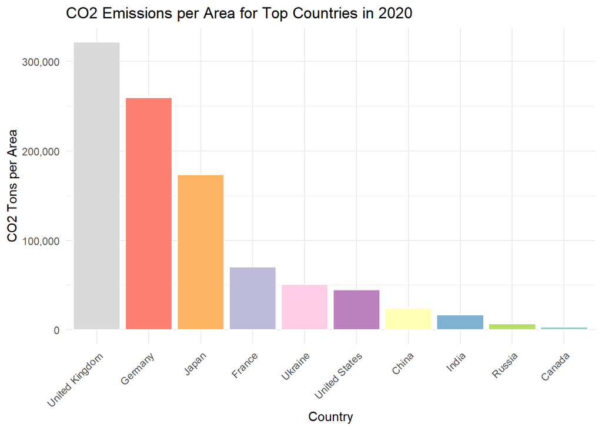

```r
ggplot(area2020, aes(x = reorder(Country, -coByArea), y = coByArea, fill = Country)) +
  geom_bar(stat = "identity", position = "dodge", color = "white") +
  theme_minimal() +
  labs(x = "Country", y = "CO2 Tons per Area") +
  ggtitle("CO2 Emissions per Area for Top Countries in 2020") +
  theme(axis.text.x = element_text(angle = 45, hjust = 1, vjust = 1),
        legend.position = "none") +
  scale_fill_brewer(palette = "Set3") + scale_y_continuous(labels = scales::comma)
```

### **Developing vs Developed Countries**

```r
gdp_threshold <- 25000

df_categorized <- wdi_data %>%
  mutate(GDP_per_capita = NY.GDP.MKTP.KD / SP.POP.TOTL)


df_categorized <- df_categorized %>%
  mutate(development_status = ifelse(GDP_per_capita >= gdp_threshold, "Developed", "Developing"))

df_categorized <- na.omit(df_categorized)

developed_countries <- df_categorized %>%
  filter(development_status == "Developed")

developing_countries <- df_categorized %>%
  filter(development_status == "Developing")
```

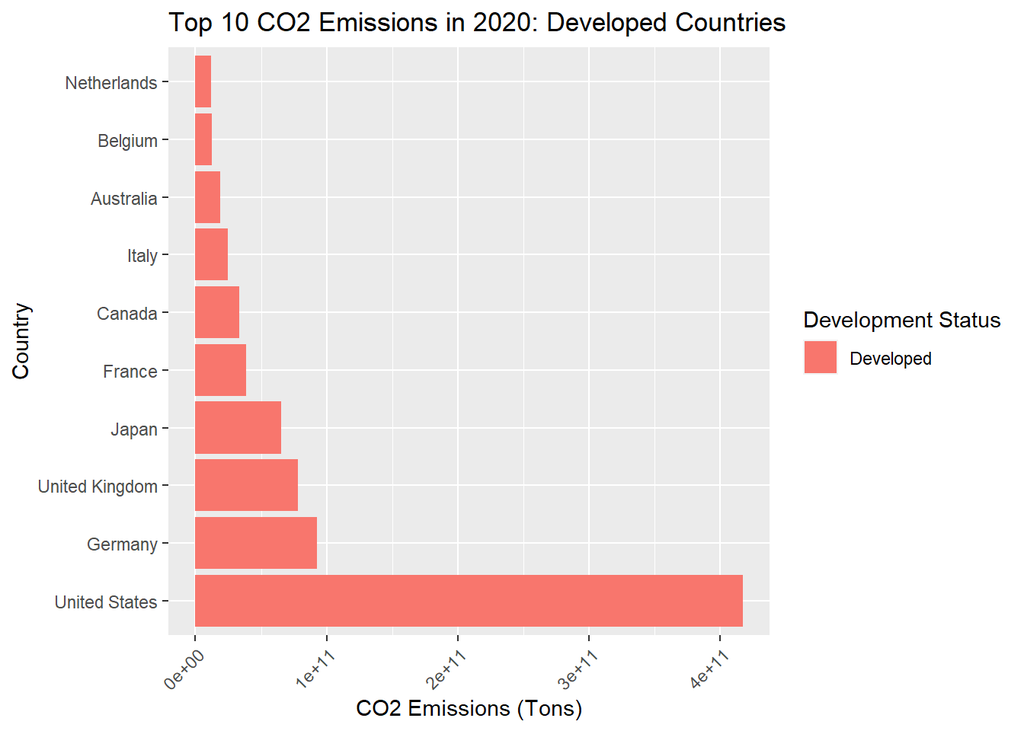

```r
emissions_2020 <- df_categorized %>%
  filter(Year == 2020)

top_developed <- emissions_2020 %>%
  filter(development_status == "Developed") %>%
  top_n(10, wt = CO2.emission..Tons.)

top_developing <- emissions_2020 %>%
  filter(development_status == "Developing") %>%
  top_n(10, wt = CO2.emission..Tons.)

# Plot emissions for the top 10 developed countries in 2020
developed_plot <- ggplot(top_developed, aes(x = reorder(Country, -CO2.emission..Tons.), y = CO2.emission..Tons., fill = development_status)) +
  geom_bar(stat = "identity") +
  labs(title = "Top 10 CO2 Emissions in 2020: Developed Countries",
       x = "Country",
       y = "CO2 Emissions (Tons)",
       fill = "Development Status") +
  theme(axis.text.x = element_text(angle = 45, hjust = 1)) +
  coord_flip()

# Plot emissions for the top 10 developing countries in 2020
developing_plot <- ggplot(top_developing, aes(x = reorder(Country, -CO2.emission..Tons.), y = CO2.emission..Tons., fill = development_status)) +
  geom_bar(stat = "identity") +
  labs(title = "Top 10 CO2 Emissions in 2020: Developing Countries",
       x = "Country",
       y = "CO2 Emissions (Tons)",
       fill = "Development Status") +
  theme(axis.text.x = element_text(angle = 45, hjust = 1)) +
  coord_flip()

print(developed_plot)
```

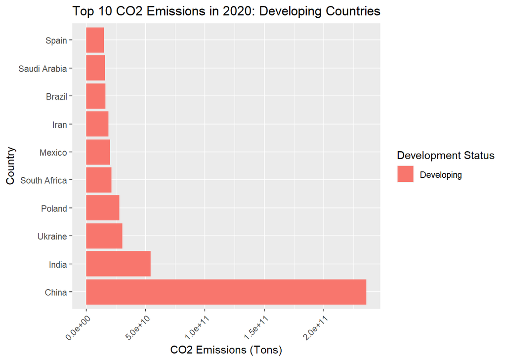

```r
print(developing_plot)
```

*India is 2nd to China in terms of CO2 emissions. As more companies attempt to gain a foothold in India for setting up manufacturing plants, it would be interesting to see in the future whether India’s CO2 emissions rise as China’s falls*

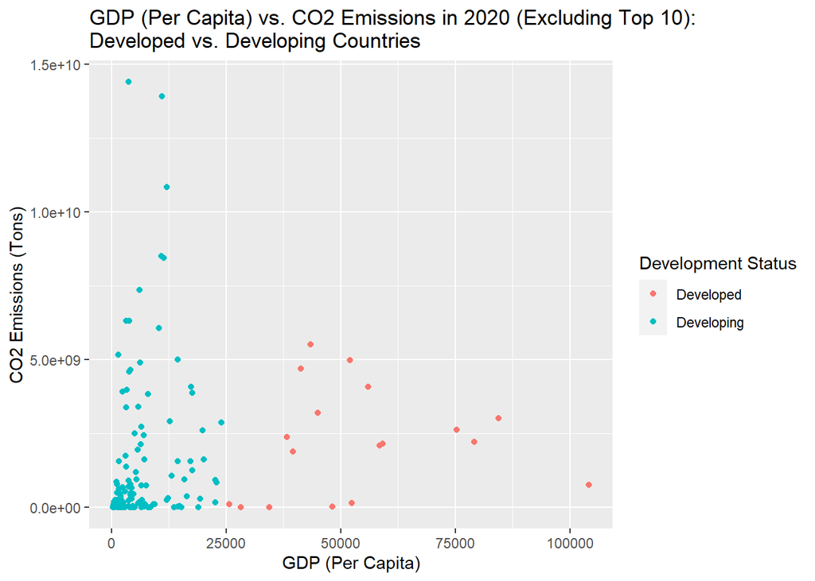

```r
emissions_2020_excluded <- anti_join(emissions_2020, top_developed, by = c("Country", "development_status"))
emissions_2020_excluded <- anti_join(emissions_2020_excluded, top_developing, by = c("Country", "development_status"))

# Scatter plot of GDP (Per Capita) vs. CO2 emissions for 2020 (excluding top 10)
ggplot(emissions_2020_excluded, aes(x = GDP_per_capita, y = CO2.emission..Tons., color = development_status)) +
  geom_point() +
  labs(title = "GDP (Per Capita) vs. CO2 Emissions in 2020 (Excluding Top 10):\nDeveloped vs. Developing Countries",
       x = "GDP (Per Capita)",
       y = "CO2 Emissions (Tons)",
       color = "Development Status")
```

*Analyzing the relationship between GDP (Per Capita) and CO2 emissions while distinguishing between developing and developed countries offers insights into the impact of climate agreements. Traditionally, nations with higher GDP have often taken the lead in establishing and adhering to climate goals, a trend that aligns with the observations depicted in the plot.*

## **Conclusion**

Our analysis provides valuable insights into the changing landscape of CO2 emissions. We observed historical emission patterns, the impact of international agreements, and the contributions of specific countries. Understanding these trends is crucial for policymakers and stakeholders working towards sustainable environmental practices.

**Historical Emission Patterns**

Our exploration of historical emission patterns provided a comprehensive view of how different countries have contributed to the cumulative CO2 emissions since 1750. By identifying the starting points of recorded emissions for each country, we gained insights into the trajectories of their carbon footprints over time. This historical context aids in understanding the varying roles nations have played in the global emissions landscape.

**Significance for Policymakers and Stakeholders**

The insights derived from our analysis carry significant implications for policymakers and stakeholders dedicated to environmental sustainability. Policymakers can leverage this information to design tailored strategies for emission reduction, accounting for historical contributions and the impact of international collaborations. Stakeholders, including environmental organizations and businesses, can use these findings to align their efforts with global objectives and contribute to a more sustainable and resilient future.

**Future Considerations**

As we progress towards a more environmentally conscious future, continued monitoring and analysis of CO2 emissions remain imperative. Ongoing assessments will enable us to evaluate the effectiveness of current policies, identify emerging trends, and adapt strategies to address evolving challenges. Additionally, exploring the intersection of CO2 emissions with socioeconomic factors, technological advancements, and policy implementations can provide a holistic understanding of the forces shaping our environmental trajectory.

In conclusion, our analysis not only illuminates the historical context of CO2 emissions but also offers a roadmap for informed decision-making in the pursuit of a sustainable and resilient global ecosystem. As we collectively strive for a greener future, the lessons drawn from this study can serve as valuable guides for shaping impactful policies and fostering a shared commitment to environmental stewardship.